# Expository graphs

## Why do we use graphs in data analysis?

- To understand data properties
- To find patterns in data
- To suggest modeling strategies
- To "debug" analyses
- To communicate results

## Expository graphs

- To understand data properties
- To find patterns in data
- To suggest modeling strategies
- To "debug" analyses
- To communicate results

## Characteristics of expository graphs

- The goal is to communicate information
- Information density is generally good
- Color/size are used both for aesthetics and communication
- Expository figures have understandable axes, titles, and legends

## Housing data

[figure not shown]

```r
pData <- read.csv("./data/ss06pid.csv")
```

## Axes

Important parameters: *xlab*,*ylab*,*cex.lab*,*cex.axis*

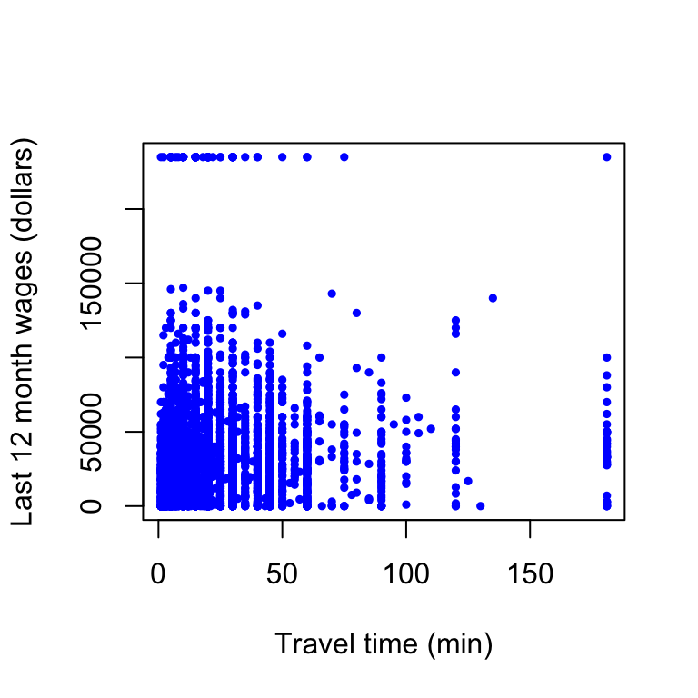

```r
plot(pData$JWMNP,pData$WAGP,pch=19,col="blue",cex=0.5,
     xlab="Travel time (min)",ylab="Last 12 month wages (dollars)")
```

## Axes

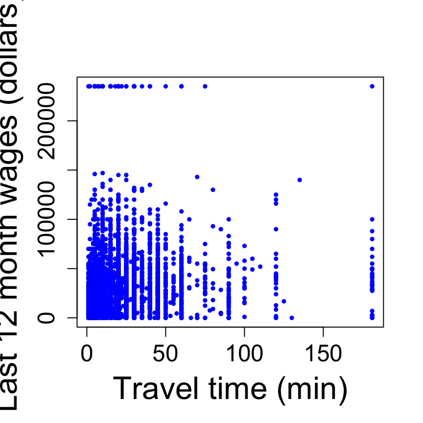

```r
plot(pData$JWMNP,pData$WAGP,pch=19,col="blue",cex=0.5,
     xlab="Travel time (min)",ylab="Last 12 month wages (dollars)",cex.lab=2,cex.axis=1.5)
```

## Legends

- Important paramters: *x*,*y*,*legend*, *other plotting parameters*

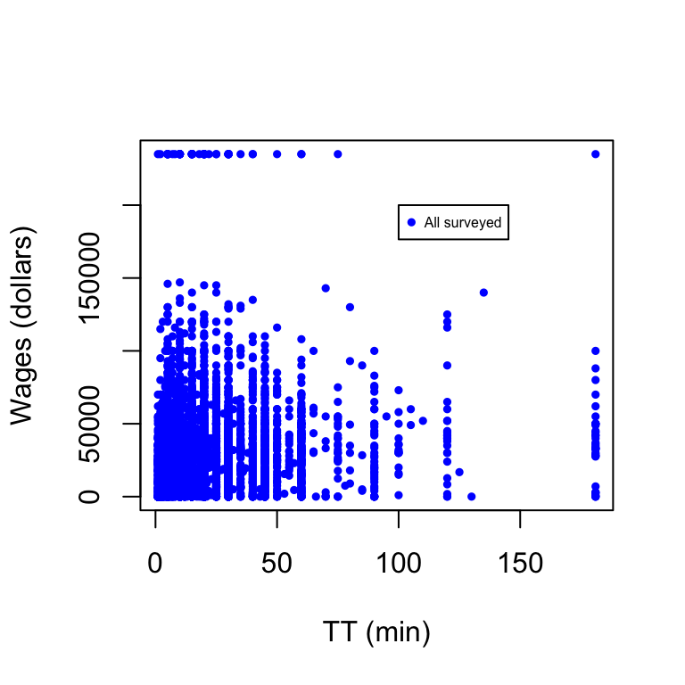

```r
plot(pData$JWMNP,pData$WAGP,pch=19,col="blue",cex=0.5,xlab="TT (min)",ylab="Wages (dollars)")
legend(100,200000,legend="All surveyed",col="blue",pch=19,cex=0.5)
```

## Legends

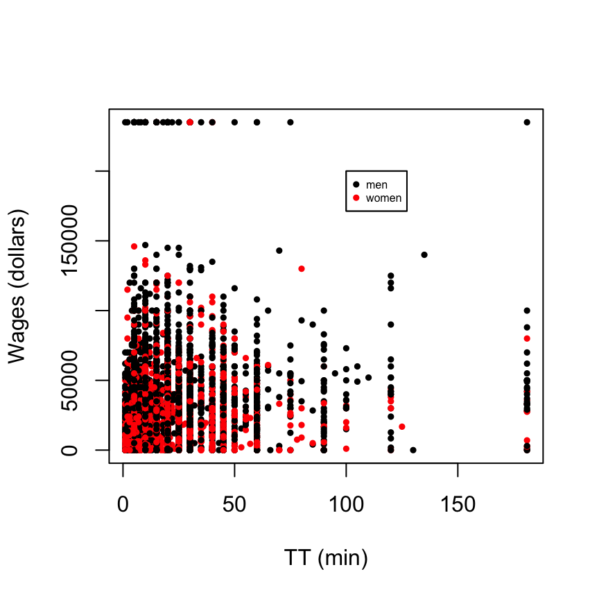

```r
plot(pData$JWMNP,pData$WAGP,pch=19,cex=0.5,xlab="TT (min)",ylab="Wages (dollars)",col=pData$SEX)
legend(100,200000,legend=c("men","women"),col=c("black","red"),pch=c(19,19),cex=c(0.5,0.5))
```

## Titles

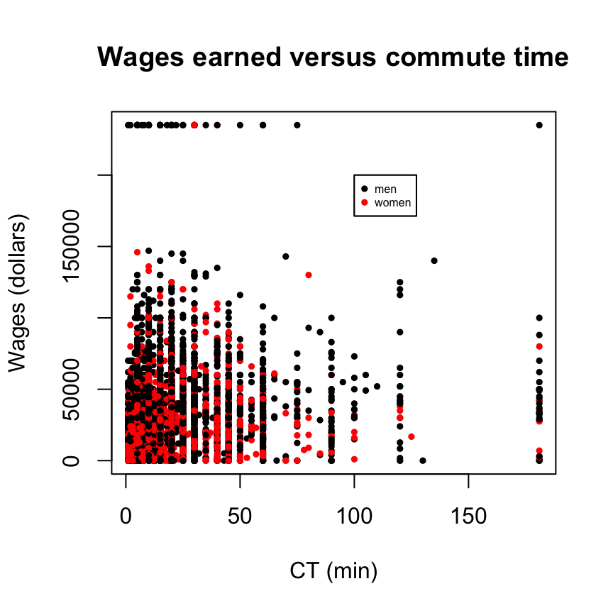

```r
plot(pData$JWMNP,pData$WAGP,pch=19,cex=0.5,xlab="CT (min)",
     ylab="Wages (dollars)",col=pData$SEX,main="Wages earned versus commute time")
legend(100,200000,legend=c("men","women"),col=c("black","red"),pch=c(19,19),cex=c(0.5,0.5))
```

## Multiple panels

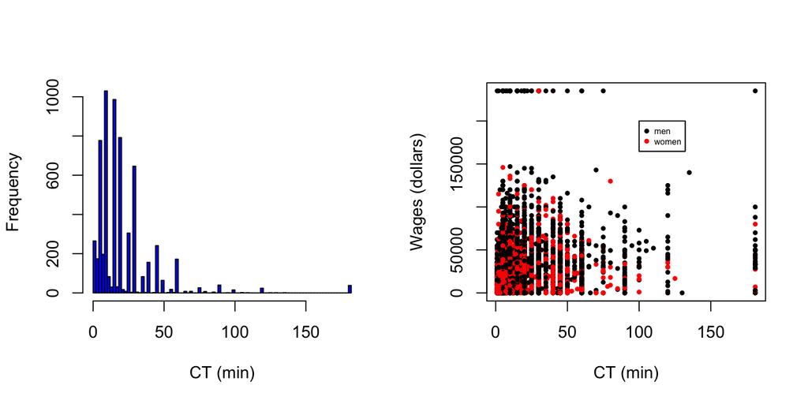

```r
par(mfrow=c(1,2))
hist(pData$JWMNP,xlab="CT (min)",col="blue",breaks=100,main="")
plot(pData$JWMNP,pData$WAGP,pch=19,cex=0.5,xlab="CT (min)",ylab="Wages (dollars)",col=pData$SEX)
legend(100,200000,legend=c("men","women"),col=c("black","red"),pch=c(19,19),cex=c(0.5,0.5))
```

## Adding text

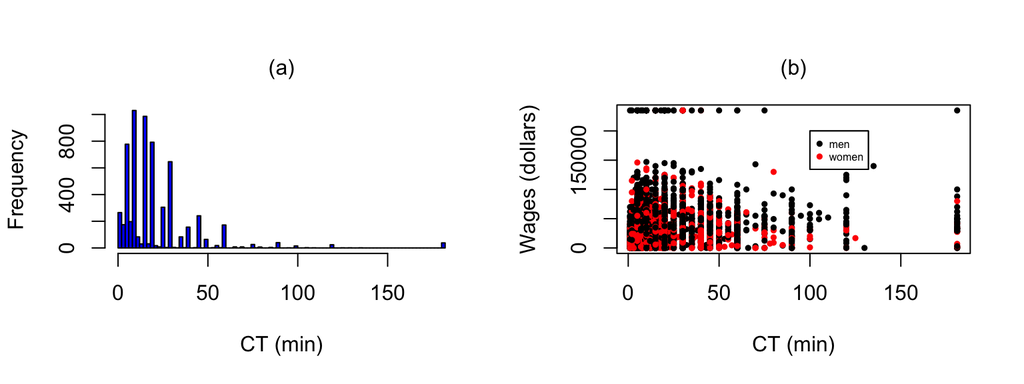

```r
par(mfrow=c(1,2))
hist(pData$JWMNP,xlab="CT (min)",col="blue",breaks=100,main="")
mtext(text="(a)",side=3,line=1)
plot(pData$JWMNP,pData$WAGP,pch=19,cex=0.5,xlab="CT (min)",ylab="Wages (dollars)",col=pData$SEX)
legend(100,200000,legend=c("men","women"),col=c("black","red"),pch=c(19,19),cex=c(0.5,0.5))
mtext(text="(b)",side=3,line=1)
```

## Figure captions

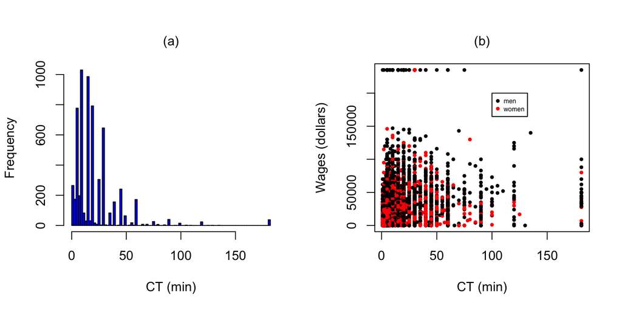

**Figure 1. Distribution of commute time and relationship to wage earned by sex** **(a)** Commute times in the American Community Survey (ACS) are right skewed. **(b)** Commute times do not appear to be strongly correlated with wage for either sex.

## Colorblindness

[figure not shown]

[http://www.vischeck.com/](http://www.vischeck.com/vischeck/vischeckImage.php)

## Graphical workflow

- Start with a rough plot
- Tweak it to make it expository
- Save the file
- Include it in presentations

## Something to avoid

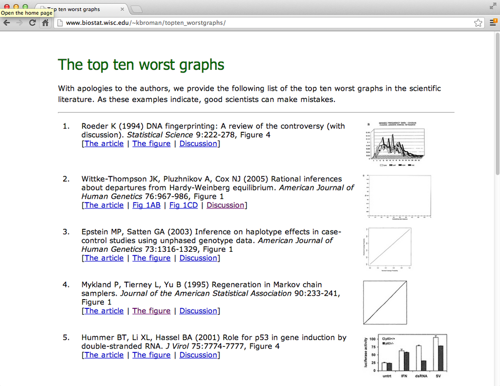

http://www.biostat.wisc.edu/~kbroman/topten_worstgraphs/

## Something to aspire to

[figure not shown]

http://www.facebook.com/notes/facebook-engineering/visualizing-friendships/469716398919

## Further resources

- [How to display data badly](http://www.jstor.org/discover/10.2307/2683253?uid=3739704&uid=2&uid=4&uid=3739256&sid=21101619120151)
- [The visual display of quantitative information](http://www.amazon.com/exec/obidos/ASIN/0961392142/7210-20)
- [Creating more effective graphs](http://www.amazon.com/exec/obidos/ASIN/047127402X/7210-20)
- [R Graphics Cookbook](http://www.amazon.com/R-Graphics-Cookbook-Winston-Chang/dp/1449316956)
- [ggplot2: Elegant Graphics for Data Analysis](http://www.amazon.com/ggplot2-Elegant-Graphics-Data-Analysis/dp/0387981403)
- [Flowing Data](http://flowingdata.com/)